# Bikes

Kasia

2023-06-08

### Cyclistic Analysis

#### Installing required packages

#### tidyverse for data import and wrangling

#### lubridate for date functions

#### ggplot2 for visualizations

### Data Analysis Project

Data Analyst: (Kasia Grzegorowska)  
Client/Sponsor: Cyclistic bike-share – How does a bike-share navigate speed success?  
Purpose:  
About the company:  
In 2016, Cyclistic launched a successful bike-share offering. Since then, the program has grown to a fleet of 5824 bicycles that are geotracked and locked into a network of 692 station across Chicago. The bikes can be unlocked from one station and returned to any other station in the system anytime. Cyclistic sets itself apart by also offering reclining bikes, hand tricycles and cargo bikes, making bike-share more inclusive to people with disabilities and riders who can’t use a standard two-wheeled bike. The majority of riders opt for traditional bikes, about 8% of riders use the assistive options. Cyclistic users are more likely to ride of leisure, but about 30% use them to commute to work each day.  
Until now, Cyclistic’s marketing strategy relied on building general awareness and appealing to broad consumer segments. One approach that helped make these things possible was the flexibility of its pricing plans: single-ride passes, full-day passes, and annual memberships. Customers who purchase single-ride or full-day passes are referred to as casual riders. Customers who purchase annual memberships are Cyclistic members.  
Cyclistic’s finance analysts have concluded that annual members are much more profitable than casual riders. Although the pricing flexibility helps Cyclistic attract more customers, the director of marketing believes that maximizing the number of annual members will be key to future growth. Rather than creating a marketing campaign that targets all-new customers, the director of marketing believes there is a very good chance to convert casual riders into members. She notes that casual riders are already aware of the Cyclistic program and have chosen Cyclistic for their mobility needs.  
Why is this project happening?  
This project is happening because the company wants to maximize the number of annual memberships. In order to maximize the number of annual memberships, which are much more profitable than casual riders, the marketing analyst team needs to better understand the following:  
1. How do annual members and casual riders use Ciclistic bikes differently?  
2. Why would casual riders buy Cyclistic annual memberships?  
3. How can Cyclistic use digital media to influence casual riders to become members?  
What are the goals?  
The goal is to design marketing strategies aimed at converting casual riders into annual members to ensure the future growth of the company by analyzing how annual members and casual riders use Cyclistic bikes differently.  
The final deliverable will recommend three top recommendation supported by visualizations and key findings.  
Scope / Major Project Activities:  
Identify the business task and consider key stakeholders - Define the problem I’m trying to solve and understand the stakeholders’ expectations, define and identify my audience and key stakeholders.  
Prepare the data for analysis - download data, identify how it’s organized, sort and filter, determine its credibility  
Process the data for analysis - checking data for errors, choosing the tools, transforming the data to be more effective, documenting the cleaning process  
Create recommendations  
Deliver final report  
● This project does not involve the analysis of why casual riders would buy Cyclistic annual memberships  
● This project does not involve the analysis of how Cyclistic can use digital media to influence casual riders to become members  
1. Statement of the business task  
Cyclistic company have got 2 types of customers: annual members and casual riders. Annual member are much more profitable than casual riders so maximizing the number of annual members will be key to future growth. The problem that this analysis is trying to solve is to understand how annual members and casual riders use Cyclistic bikes differently.  
Insights from this analysis will create a framework of marketing strategies aimed at converting casual riders into annual members.  
This problem can be solved by analyzing the Cyclistic historical bike trip data to identify trends which will be used as a framework for a new marketing strategy.  
To do the task, the previous 12 months of Cyclistic trip data will be used showing also the holiday months, which can differ from the rest of the months.<br) In case of conducting additional research, qualitative data would help solving the problem with questions like ‘Under what circumstances would you choose a membership over a casual rides?’.  
The audience for the presentation are the director of marketing, Cyclistic marketing analytics team and Cyclistic executive team.  
The scope of the task is to answer the question of how annual members and casual riders use Cyclistic bike differently only.  
The other two questions are considered out of scope.  
Access to the information will be given to the director of marketing and the marketing analytics team.  
2. Description of all data sources used  
The data from the company’s resources has been downloaded onto my computer. A folder with two subfoldes has been created: one subfolder to house .xls files and the second subfolder to house .csv files to have a copy of the original data.  
There are spreadsheet datasets containing previous 12 months of Cyclistic trip data. It is an internal data, which lives inside the company’s system. It is a structured data organized into rows and columns.  
The data is reliable and credible because it comes from the historical trip data and was collected by the company. It is original and comprehensive data, which will allow to answer the business question.  
The data will be protected from unauthorized access or corruption by adopting safety measures.  
The data has been made available by Motivate International Inc. under the licence. To ensure data-privacy and security of the riders, their personally identifiable information are prohibited to use.  
The data is relevant and aligned with business objective because it allows tracking trends over a long period of time – 12 months including holiday months, which can differ from the rest of months.  
There is some data showing the age and gender of the customers, which could be useful to determine the differences between the annual and casual riders divided into age and gender groups but there is only outdated data available from 2019, which could be used as proxy data.  
The confidentiality of the data will be maintained during the analysis.  
To check the overall data integrity I did a quick analysis of the datasets. I checked the data format because calendar dates can be represented in a lots of different short formats. To ensure data integrity I used DMY date format.  
I also sorted the date by started_at columns (oldest to newest) to make is easier to understand, analyze and visualize.  
3. Data cleaning  
Data set contain 4 files containing previous 12 months of Cyclistic trip data.  
Each file contains the following columns:  
- ride_id, rideable_type, started_at, ended_at, start_station_name, start_station_id, end_station_name, end_station_id, start_lat, start_lng, end_lat, end_lng, member_casual.  
- Initial analysis of how the data is organized  
- Sorting and filtering  
- Checking the data for errors  
- Removing duplicates  
- Transforming the data so I can work with it effectively  
- Working with individual spreadsheets to get a better sense of the data layout: calculating the length of each ride, calculating the day of the week that each ride started  
4. Data processing  
- Running a few calculations in one file to understand the data better, calculating the mean of ride length, calculating the max ride length, calculating the average ride length per day, calculating the type of bikes used  
- Performing the same analysis on another file  
- Exploring different seasons to make some initial observations  
- Merging 4 files into a full-year view  
5. Data analyzing

```r
library(tidyverse)
```

```r
library(lubridate)
library(ggplot2)
```

#### Uploading data sets (.csv files)

```r
q2_2019 <- read_csv("C:/Users/Ubezpieczenia/OneDrive/Dokumenty/Google Data Analytics Certificate/8_Capstone/Divvy_tripdata_csv/Divvy_Trips_2019_Q2.csv")
q3_2019 <- read_csv("C:/Users/Ubezpieczenia/OneDrive/Dokumenty/Google Data Analytics Certificate/8_Capstone/Divvy_tripdata_csv/Divvy_Trips_2019_Q3.csv")
q4_2019 <- read_csv("C:/Users/Ubezpieczenia/OneDrive/Dokumenty/Google Data Analytics Certificate/8_Capstone/Divvy_tripdata_csv/Divvy_Trips_2019_Q4.csv")
q1_2020 <- read_csv("C:/Users/Ubezpieczenia/OneDrive/Dokumenty/Google Data Analytics Certificate/8_Capstone/Divvy_tripdata_csv/Divvy_Trips_2020_Q1.csv")
```

#### Checking columns names of the files to see if they match

```r
colnames(q2_2019)
```

```
##  [1] "01 - Rental Details Rental ID"
##  [2] "01 - Rental Details Local Start Time"
##  [3] "01 - Rental Details Local End Time"
##  [4] "01 - Rental Details Bike ID"
##  [5] "01 - Rental Details Duration In Seconds Uncapped"
##  [6] "03 - Rental Start Station ID"
##  [7] "03 - Rental Start Station Name"
##  [8] "02 - Rental End Station ID"
##  [9] "02 - Rental End Station Name"
## [10] "User Type"
## [11] "Member Gender"
## [12] "05 - Member Details Member Birthday Year"
```

```r
glimpse(q2_2019)
```

```
## Rows: 1,048,575
## Columns: 12
## $ `01 - Rental Details Rental ID`                    <chr> "22178529", "221785…
## $ `01 - Rental Details Local Start Time`             <dttm> 2019-04-01 00:02:2…
## $ `01 - Rental Details Local End Time`               <dttm> 2019-04-01 00:09:4…
## $ `01 - Rental Details Bike ID`                      <dbl> 6251, NA, 5649, 415…
## $ `01 - Rental Details Duration In Seconds Uncapped` <dbl> 446, NA, 252, 357, …
## $ `03 - Rental Start Station ID`                     <dbl> 81, NA, 283, 26, NA…
## $ `03 - Rental Start Station Name`                   <chr> "Daley Center Plaza…
## $ `02 - Rental End Station ID`                       <dbl> 56, NA, 174, 133, N…
## $ `02 - Rental End Station Name`                     <chr> "Desplaines St & Ki…
## $ `User Type`                                        <chr> "Subscriber", NA, "…
## $ `Member Gender`                                    <chr> "Male", NA, "Male",…
## $ `05 - Member Details Member Birthday Year`         <dbl> 1975, NA, 1990, 199…
```

```r
colnames(q3_2019)
```

```
##  [1] "trip_id"           "start_time"        "end_time"
##  [4] "bikeid"            "tripduration"      "from_station_id"
##  [7] "from_station_name" "to_station_id"     "to_station_name"
## [10] "usertype"          "gender"            "birthyear"
```

```r
glimpse(q3_2019)
```

```
## Rows: 1,048,575
## Columns: 12
## $ trip_id           <chr> "23479388,2019-07-01 00:00:27,2019-07-01 00:20:41,35…
## $ start_time        <dttm> NA, NA, NA, NA, NA, 2019-07-01 00:02:21, NA, NA, NA…
## $ end_time          <dttm> NA, NA, NA, NA, NA, 2019-07-01 00:07:31, NA, NA, NA…
## $ bikeid            <dbl> NA, NA, NA, NA, NA, 4941, NA, NA, NA, NA, NA, NA, NA…
## $ tripduration      <dbl> NA, NA, NA, NA, NA, 310, NA, NA, NA, NA, NA, NA, NA,…
## $ from_station_id   <dbl> NA, NA, NA, NA, NA, 300, NA, NA, NA, NA, NA, NA, NA,…
## $ from_station_name <chr> NA, NA, NA, NA, NA, "Broadway & Barry Ave", NA, NA, …
## $ to_station_id     <dbl> NA, NA, NA, NA, NA, 232, NA, NA, NA, NA, NA, NA, NA,…
## $ to_station_name   <chr> NA, NA, NA, NA, NA, "Pine Grove Ave & Waveland Ave",…
## $ usertype          <chr> NA, NA, NA, NA, NA, "Subscriber", NA, NA, NA, NA, NA…
## $ gender            <chr> NA, NA, NA, NA, NA, "Male", NA, NA, NA, NA, NA, NA, …
## $ birthyear         <dbl> NA, NA, NA, NA, NA, 1990, NA, NA, NA, NA, NA, NA, NA…
```

```r
colnames(q4_2019)
```

```
##  [1] "trip_id"           "start_time"        "end_time"
##  [4] "bikeid"            "tripduration"      "from_station_id"
##  [7] "from_station_name" "to_station_id"     "to_station_name"
## [10] "usertype"          "gender"            "birthyear"
```

```r
glimpse(q4_2019)
```

```
## Rows: 704,054
## Columns: 12
## $ trip_id           <chr> "25223640", "25223641", "25223642", "25223643,2019-1…
## $ start_time        <dttm> 2019-10-01 00:01:39, 2019-10-01 00:02:16, 2019-10-0…
## $ end_time          <dttm> 2019-10-01 00:17:20, 2019-10-01 00:06:34, 2019-10-0…
## $ bikeid            <dbl> 2215, 6328, 3003, NA, NA, 1891, NA, NA, NA, NA, NA, …
## $ tripduration      <dbl> 940, 258, 850, NA, NA, 373, NA, NA, NA, NA, NA, 748,…
## $ from_station_id   <dbl> 20, 19, 84, NA, NA, 156, NA, NA, NA, NA, NA, 198, NA…
## $ from_station_name <chr> "Sheffield Ave & Kingsbury St", "Throop (Loomis) St …
## $ to_station_id     <dbl> 309, 241, 199, NA, NA, 226, NA, NA, NA, NA, NA, 331,…
## $ to_station_name   <chr> "Leavitt St & Armitage Ave", "Morgan St & Polk St", …
## $ usertype          <chr> "Subscriber", "Subscriber", "Subscriber", NA, NA, "S…
## $ gender            <chr> "Male", "Male", "Female", NA, NA, "Female", NA, NA, …
## $ birthyear         <dbl> 1987, 1998, 1991, NA, NA, 1994, NA, NA, NA, NA, NA, …
```

```r
colnames(q1_2020)
```

```
##  [1] "ride_id"            "rideable_type"      "started_at"
##  [4] "ended_at"           "start_station_name" "start_station_id"
##  [7] "end_station_name"   "end_station_id"     "start_lat"
## [10] "start_lng"          "end_lat"            "end_lng"
## [13] "member_casual"
```

```r
glimpse(q1_2020)
```

```
## Rows: 426,887
## Columns: 13
## $ ride_id            <chr> "EACB19130B0CDA4A", "8FED874C809DC021", "789F3C21E4…
## $ rideable_type      <chr> "docked_bike", "docked_bike", "docked_bike", "docke…
## $ started_at         <dttm> 2020-01-21 20:06:59, 2020-01-30 14:22:39, 2020-01-…
## $ ended_at           <dttm> 2020-01-21 20:14:30, 2020-01-30 14:26:22, 2020-01-…
## $ start_station_name <chr> "Western Ave & Leland Ave", "Clark St & Montrose Av…
## $ start_station_id   <dbl> 239, 234, 296, 51, 66, 212, 96, 96, 212, 38, 117, 1…
## $ end_station_name   <chr> "Clark St & Leland Ave", "Southport Ave & Irving Pa…
## $ end_station_id     <dbl> 326, 318, 117, 24, 212, 96, 212, 212, 96, 100, 632,…
## $ start_lat          <dbl> 41.9665, 41.9616, 41.9401, 41.8846, 41.8856, 41.889…
## $ start_lng          <dbl> -87.6884, -87.6660, -87.6455, -87.6319, -87.6418, -…
## $ end_lat            <dbl> 41.9671, 41.9542, 41.9402, 41.8918, 41.8899, 41.884…
## $ end_lng            <dbl> -87.6674, -87.6644, -87.6530, -87.6206, -87.6343, -…
## $ member_casual      <chr> "member", "member", "member", "member", "member", "…
```

#### Changing columns names to match q1_2020 file

```r
q2_2019_renamed <- q2_2019 %>%
  rename(ride_id = "01 - Rental Details Rental ID", rideable_type = "01 - Rental Details Bike ID", started_at = "01 - Rental Details Local Start Time",
         ended_at = "01 - Rental Details Local End Time", start_station_name = "03 - Rental Start Station Name", start_station_id = "03 - Rental Start Station ID",
         end_station_name = "02 - Rental End Station Name", end_station_id = "02 - Rental End Station ID", member_casual = "User Type")

q3_2019_renamed <- q3_2019 %>%
  rename(ride_id = trip_id, rideable_type = bikeid, started_at = start_time, ended_at = end_time, start_station_name = from_station_name, start_station_id = from_station_id,
         end_station_name = to_station_name, end_station_id = to_station_id, member_casual = usertype)

q4_2019_renamed <- q4_2019 %>%
  rename(ride_id = trip_id, rideable_type = bikeid, started_at = start_time, ended_at = end_time, start_station_name = from_station_name, start_station_id = from_station_id,
         end_station_name = to_station_name, end_station_id = to_station_id, member_casual = usertype)
```

#### Checking the new dataframes

```r
str(q2_2019_renamed)
```

```
## spc_tbl_ [1,048,575 × 12] (S3: spec_tbl_df/tbl_df/tbl/data.frame)
##  $ ride_id                                         : chr [1:1048575] "22178529" "22178530,2019-04-01 00:03:02,2019-04-01 00:20:30,6226,\"1,048.0\",317,Wood St & Taylor St,59,Wabash Ave & Roose"| __truncated__ "22178531" "22178532" ...
##  $ started_at                                      : POSIXct[1:1048575], format: "2019-04-01 00:02:22" NA ...
##  $ ended_at                                        : POSIXct[1:1048575], format: "2019-04-01 00:09:48" NA ...
##  $ rideable_type                                   : num [1:1048575] 6251 NA 5649 4151 NA ...
##  $ 01 - Rental Details Duration In Seconds Uncapped: num [1:1048575] 446 NA 252 357 NA 257 548 383 NA NA ...
##  $ start_station_id                                : num [1:1048575] 81 NA 283 26 NA 420 503 260 NA NA ...
##  $ start_station_name                              : chr [1:1048575] "Daley Center Plaza" NA "LaSalle St & Jackson Blvd" "McClurg Ct & Illinois St" ...
##  $ end_station_id                                  : num [1:1048575] 56 NA 174 133 NA 426 500 499 NA NA ...
##  $ end_station_name                                : chr [1:1048575] "Desplaines St & Kinzie St" NA "Canal St & Madison St" "Kingsbury St & Kinzie St" ...
##  $ member_casual                                   : chr [1:1048575] "Subscriber" NA "Subscriber" "Subscriber" ...
##  $ Member Gender                                   : chr [1:1048575] "Male" NA "Male" "Male" ...
##  $ 05 - Member Details Member Birthday Year        : num [1:1048575] 1975 NA 1990 1993 NA ...
##  - attr(*, "spec")=
##   .. cols(
##   ..   `01 - Rental Details Rental ID` = col_character(),
##   ..   `01 - Rental Details Local Start Time` = col_datetime(format = ""),
##   ..   `01 - Rental Details Local End Time` = col_datetime(format = ""),
##   ..   `01 - Rental Details Bike ID` = col_double(),
##   ..   `01 - Rental Details Duration In Seconds Uncapped` = col_double(),
##   ..   `03 - Rental Start Station ID` = col_double(),
##   ..   `03 - Rental Start Station Name` = col_character(),
##   ..   `02 - Rental End Station ID` = col_double(),
##   ..   `02 - Rental End Station Name` = col_character(),
##   ..   `User Type` = col_character(),
##   ..   `Member Gender` = col_character(),
##   ..   `05 - Member Details Member Birthday Year` = col_double()
##   .. )
##  - attr(*, "problems")=<externalptr>
```

```r
str(q3_2019_renamed)
```

```
## spc_tbl_ [1,048,575 × 12] (S3: spec_tbl_df/tbl_df/tbl/data.frame)
##  $ ride_id           : chr [1:1048575] "23479388,2019-07-01 00:00:27,2019-07-01 00:20:41,3591,\"1,214.0\",117,Wilton Ave & Belmont Ave,497,Kimball Ave "| __truncated__ "23479389,2019-07-01 00:01:16,2019-07-01 00:18:44,5353,\"1,048.0\",381,Western Ave & Monroe St,203,Western Ave &"| __truncated__ …
##  $ started_at        : POSIXct[1:1048575], format: NA NA ...
##  $ ended_at          : POSIXct[1:1048575], format: NA NA ...
##  $ rideable_type     : num [1:1048575] NA NA NA NA NA ...
##  $ tripduration      : num [1:1048575] NA NA NA NA NA 310 NA NA NA NA ...
##  $ start_station_id  : num [1:1048575] NA NA NA NA NA 300 NA NA NA NA ...
##  $ start_station_name: chr [1:1048575] NA NA NA NA ...
##  $ end_station_id    : num [1:1048575] NA NA NA NA NA 232 NA NA NA NA ...
##  $ end_station_name  : chr [1:1048575] NA NA NA NA ...
##  $ member_casual     : chr [1:1048575] NA NA NA NA ...
##  $ gender            : chr [1:1048575] NA NA NA NA ...
##  $ birthyear         : num [1:1048575] NA NA NA NA NA 1990 NA NA NA NA ...
##  - attr(*, "spec")=
##   .. cols(
##   ..   trip_id = col_character(),
##   ..   start_time = col_datetime(format = ""),
##   ..   end_time = col_datetime(format = ""),
##   ..   bikeid = col_double(),
##   ..   tripduration = col_double(),
##   ..   from_station_id = col_double(),
##   ..   from_station_name = col_character(),
##   ..   to_station_id = col_double(),
##   ..   to_station_name = col_character(),
##   ..   usertype = col_character(),
##   ..   gender = col_character(),
##   ..   birthyear = col_double()
##   .. )
##  - attr(*, "problems")=<externalptr>
```

```r
str(q4_2019_renamed)
```

```
## spc_tbl_ [704,054 × 12] (S3: spec_tbl_df/tbl_df/tbl/data.frame)
##  $ ride_id           : chr [1:704054] "25223640" "25223641" "25223642" "25223643,2019-10-01 00:04:32,2019-10-01 00:43:43,3275,\"2,350.0\",313,Lakeview Ave & Fullerton Pkwy,290,Kedzie "| __truncated__ ...
##  $ started_at        : POSIXct[1:704054], format: "2019-10-01 00:01:39" "2019-10-01 00:02:16" ...
##  $ ended_at          : POSIXct[1:704054], format: "2019-10-01 00:17:20" "2019-10-01 00:06:34" ...
##  $ rideable_type     : num [1:704054] 2215 6328 3003 NA NA ...
##  $ tripduration      : num [1:704054] 940 258 850 NA NA 373 NA NA NA NA ...
##  $ start_station_id  : num [1:704054] 20 19 84 NA NA 156 NA NA NA NA ...
##  $ start_station_name: chr [1:704054] "Sheffield Ave & Kingsbury St" "Throop (Loomis) St & Taylor St" "Milwaukee Ave & Grand Ave" NA ...
##  $ end_station_id    : num [1:704054] 309 241 199 NA NA 226 NA NA NA NA ...
##  $ end_station_name  : chr [1:704054] "Leavitt St & Armitage Ave" "Morgan St & Polk St" "Wabash Ave & Grand Ave" NA ...
##  $ member_casual     : chr [1:704054] "Subscriber" "Subscriber" "Subscriber" NA ...
##  $ gender            : chr [1:704054] "Male" "Male" "Female" NA ...
##  $ birthyear         : num [1:704054] 1987 1998 1991 NA NA ...
##  - attr(*, "spec")=
##   .. cols(
##   ..   trip_id = col_character(),
##   ..   start_time = col_datetime(format = ""),
##   ..   end_time = col_datetime(format = ""),
##   ..   bikeid = col_double(),
##   ..   tripduration = col_double(),
##   ..   from_station_id = col_double(),
##   ..   from_station_name = col_character(),
##   ..   to_station_id = col_double(),
##   ..   to_station_name = col_character(),
##   ..   usertype = col_character(),
##   ..   gender = col_character(),
##   ..   birthyear = col_double()
##   .. )
##  - attr(*, "problems")=<externalptr>
```

```r
str(q1_2020)
```

```
## spc_tbl_ [426,887 × 13] (S3: spec_tbl_df/tbl_df/tbl/data.frame)
##  $ ride_id           : chr [1:426887] "EACB19130B0CDA4A" "8FED874C809DC021" "789F3C21E472CA96" "C9A388DAC6ABF313" ...
##  $ rideable_type     : chr [1:426887] "docked_bike" "docked_bike" "docked_bike" "docked_bike" ...
##  $ started_at        : POSIXct[1:426887], format: "2020-01-21 20:06:59" "2020-01-30 14:22:39" ...
##  $ ended_at          : POSIXct[1:426887], format: "2020-01-21 20:14:30" "2020-01-30 14:26:22" ...
##  $ start_station_name: chr [1:426887] "Western Ave & Leland Ave" "Clark St & Montrose Ave" "Broadway & Belmont Ave" "Clark St & Randolph St" ...
##  $ start_station_id  : num [1:426887] 239 234 296 51 66 212 96 96 212 38 ...
##  $ end_station_name  : chr [1:426887] "Clark St & Leland Ave" "Southport Ave & Irving Park Rd" "Wilton Ave & Belmont Ave" "Fairbanks Ct & Grand Ave" ...
##  $ end_station_id    : num [1:426887] 326 318 117 24 212 96 212 212 96 100 ...
##  $ start_lat         : num [1:426887] 42 42 41.9 41.9 41.9 ...
##  $ start_lng         : num [1:426887] -87.7 -87.7 -87.6 -87.6 -87.6 ...
##  $ end_lat           : num [1:426887] 42 42 41.9 41.9 41.9 ...
##  $ end_lng           : num [1:426887] -87.7 -87.7 -87.7 -87.6 -87.6 ...
##  $ member_casual     : chr [1:426887] "member" "member" "member" "member" ...
##  - attr(*, "spec")=
##   .. cols(
##   ..   ride_id = col_character(),
##   ..   rideable_type = col_character(),
##   ..   started_at = col_datetime(format = ""),
##   ..   ended_at = col_datetime(format = ""),
##   ..   start_station_name = col_character(),
##   ..   start_station_id = col_double(),
##   ..   end_station_name = col_character(),
##   ..   end_station_id = col_double(),
##   ..   start_lat = col_double(),
##   ..   start_lng = col_double(),
##   ..   end_lat = col_double(),
##   ..   end_lng = col_double(),
##   ..   member_casual = col_character()
##   .. )
##  - attr(*, "problems")=<externalptr>
```

#### Convert rideable_type to character format of data

```r
q2_2019_renamed <- mutate(q2_2019_renamed, rideable_type = as.character(rideable_type))
glimpse(q2_2019_renamed)
```

```
## Rows: 1,048,575
## Columns: 12
## $ ride_id                                            <chr> "22178529", "221785…
## $ started_at                                         <dttm> 2019-04-01 00:02:2…
## $ ended_at                                           <dttm> 2019-04-01 00:09:4…
## $ rideable_type                                      <chr> "6251", NA, "5649",…
## $ `01 - Rental Details Duration In Seconds Uncapped` <dbl> 446, NA, 252, 357, …
## $ start_station_id                                   <dbl> 81, NA, 283, 26, NA…
## $ start_station_name                                 <chr> "Daley Center Plaza…
## $ end_station_id                                     <dbl> 56, NA, 174, 133, N…
## $ end_station_name                                   <chr> "Desplaines St & Ki…
## $ member_casual                                      <chr> "Subscriber", NA, "…
## $ `Member Gender`                                    <chr> "Male", NA, "Male",…
## $ `05 - Member Details Member Birthday Year`         <dbl> 1975, NA, 1990, 199…
```

```r
q3_2019_renamed <- mutate(q3_2019_renamed, rideable_type = as.character(rideable_type))
glimpse(q3_2019_renamed)
```

```
## Rows: 1,048,575
## Columns: 12
## $ ride_id            <chr> "23479388,2019-07-01 00:00:27,2019-07-01 00:20:41,3…
## $ started_at         <dttm> NA, NA, NA, NA, NA, 2019-07-01 00:02:21, NA, NA, N…
## $ ended_at           <dttm> NA, NA, NA, NA, NA, 2019-07-01 00:07:31, NA, NA, N…
## $ rideable_type      <chr> NA, NA, NA, NA, NA, "4941", NA, NA, NA, NA, NA, NA,…
## $ tripduration       <dbl> NA, NA, NA, NA, NA, 310, NA, NA, NA, NA, NA, NA, NA…
## $ start_station_id   <dbl> NA, NA, NA, NA, NA, 300, NA, NA, NA, NA, NA, NA, NA…
## $ start_station_name <chr> NA, NA, NA, NA, NA, "Broadway & Barry Ave", NA, NA,…
## $ end_station_id     <dbl> NA, NA, NA, NA, NA, 232, NA, NA, NA, NA, NA, NA, NA…
## $ end_station_name   <chr> NA, NA, NA, NA, NA, "Pine Grove Ave & Waveland Ave"…
## $ member_casual      <chr> NA, NA, NA, NA, NA, "Subscriber", NA, NA, NA, NA, N…
## $ gender             <chr> NA, NA, NA, NA, NA, "Male", NA, NA, NA, NA, NA, NA,…
## $ birthyear          <dbl> NA, NA, NA, NA, NA, 1990, NA, NA, NA, NA, NA, NA, N…
```

```r
q4_2019_renamed <- mutate(q4_2019_renamed, rideable_type = as.character(rideable_type))
glimpse(q4_2019_renamed)
```

```
## Rows: 704,054
## Columns: 12
## $ ride_id            <chr> "25223640", "25223641", "25223642", "25223643,2019-…
## $ started_at         <dttm> 2019-10-01 00:01:39, 2019-10-01 00:02:16, 2019-10-…
## $ ended_at           <dttm> 2019-10-01 00:17:20, 2019-10-01 00:06:34, 2019-10-…
## $ rideable_type      <chr> "2215", "6328", "3003", NA, NA, "1891", NA, NA, NA,…
## $ tripduration       <dbl> 940, 258, 850, NA, NA, 373, NA, NA, NA, NA, NA, 748…
## $ start_station_id   <dbl> 20, 19, 84, NA, NA, 156, NA, NA, NA, NA, NA, 198, N…
## $ start_station_name <chr> "Sheffield Ave & Kingsbury St", "Throop (Loomis) St…
## $ end_station_id     <dbl> 309, 241, 199, NA, NA, 226, NA, NA, NA, NA, NA, 331…
## $ end_station_name   <chr> "Leavitt St & Armitage Ave", "Morgan St & Polk St",…
## $ member_casual      <chr> "Subscriber", "Subscriber", "Subscriber", NA, NA, "…
## $ gender             <chr> "Male", "Male", "Female", NA, NA, "Female", NA, NA,…
## $ birthyear          <dbl> 1987, 1998, 1991, NA, NA, 1994, NA, NA, NA, NA, NA,…
```

#### Combining four individual dataframes into a full year view

```r
all_rides <- bind_rows(q2_2019_renamed, q3_2019_renamed, q4_2019_renamed, q1_2020)
glimpse(all_rides)
```

```
## Rows: 3,228,091
## Columns: 19
## $ ride_id                                            <chr> "22178529", "221785…
## $ started_at                                         <dttm> 2019-04-01 00:02:2…
## $ ended_at                                           <dttm> 2019-04-01 00:09:4…
## $ rideable_type                                      <chr> "6251", NA, "5649",…
## $ `01 - Rental Details Duration In Seconds Uncapped` <dbl> 446, NA, 252, 357, …
## $ start_station_id                                   <dbl> 81, NA, 283, 26, NA…
## $ start_station_name                                 <chr> "Daley Center Plaza…
## $ end_station_id                                     <dbl> 56, NA, 174, 133, N…
## $ end_station_name                                   <chr> "Desplaines St & Ki…
## $ member_casual                                      <chr> "Subscriber", NA, "…
## $ `Member Gender`                                    <chr> "Male", NA, "Male",…
## $ `05 - Member Details Member Birthday Year`         <dbl> 1975, NA, 1990, 199…
## $ tripduration                                       <dbl> NA, NA, NA, NA, NA,…
## $ gender                                             <chr> NA, NA, NA, NA, NA,…
## $ birthyear                                          <dbl> NA, NA, NA, NA, NA,…
## $ start_lat                                          <dbl> NA, NA, NA, NA, NA,…
## $ start_lng                                          <dbl> NA, NA, NA, NA, NA,…
## $ end_lat                                            <dbl> NA, NA, NA, NA, NA,…
## $ end_lng                                            <dbl> NA, NA, NA, NA, NA,…
```

#### Removing variables which will not be needed

```r
all_rides <- all_rides %>%
  select(-c(start_lat, start_lng, end_lat, end_lng, birthyear, gender, "01 - Rental Details Duration In Seconds Uncapped", "Member Gender", "05 - Member Details Member Birthday Year",
            "tripduration"))
```

#### Checking the new dataframe

```r
colnames(all_rides)
```

```
## [1] "ride_id"            "started_at"         "ended_at"
## [4] "rideable_type"      "start_station_id"   "start_station_name"
## [7] "end_station_id"     "end_station_name"   "member_casual"
```

```r
nrow(all_rides)
```

```
## [1] 3228091
```

```r
dim(all_rides)
```

```
## [1] 3228091       9
```

```r
head(all_rides)
```

```
## # A tibble: 6 × 9
##   ride_id started_at          ended_at            rideable_type start_station_id
##   <chr>   <dttm>              <dttm>              <chr>                    <dbl>
## 1 "22178… 2019-04-01 00:02:22 2019-04-01 00:09:48 6251                        81
## 2 "22178… NA                  NA                  <NA>                        NA
## 3 "22178… 2019-04-01 00:11:07 2019-04-01 00:15:19 5649                       283
## 4 "22178… 2019-04-01 00:13:01 2019-04-01 00:18:58 4151                        26
## 5 "22178… NA                  NA                  <NA>                        NA
## 6 "22178… 2019-04-01 00:19:39 2019-04-01 00:23:56 3123                       420
## # ℹ 4 more variables: start_station_name <chr>, end_station_id <dbl>,
## #   end_station_name <chr>, member_casual <chr>
```

```r
str(all_rides)
```

```
## tibble [3,228,091 × 9] (S3: tbl_df/tbl/data.frame)
##  $ ride_id           : chr [1:3228091] "22178529" "22178530,2019-04-01 00:03:02,2019-04-01 00:20:30,6226,\"1,048.0\",317,Wood St & Taylor St,59,Wabash Ave & Roose"| __truncated__ "22178531" "22178532" ...
##  $ started_at        : POSIXct[1:3228091], format: "2019-04-01 00:02:22" NA ...
##  $ ended_at          : POSIXct[1:3228091], format: "2019-04-01 00:09:48" NA ...
##  $ rideable_type     : chr [1:3228091] "6251" NA "5649" "4151" ...
##  $ start_station_id  : num [1:3228091] 81 NA 283 26 NA 420 503 260 NA NA ...
##  $ start_station_name: chr [1:3228091] "Daley Center Plaza" NA "LaSalle St & Jackson Blvd" "McClurg Ct & Illinois St" ...
##  $ end_station_id    : num [1:3228091] 56 NA 174 133 NA 426 500 499 NA NA ...
##  $ end_station_name  : chr [1:3228091] "Desplaines St & Kinzie St" NA "Canal St & Madison St" "Kingsbury St & Kinzie St" ...
##  $ member_casual     : chr [1:3228091] "Subscriber" NA "Subscriber" "Subscriber" ...
```

```r
summary(all_rides)
```

```
##    ride_id            started_at
##  Length:3228091     Min.   :2019-04-01 00:02:22.00
##  Class :character   1st Qu.:2019-06-16 00:53:27.00
##  Mode  :character   Median :2019-08-11 23:15:22.00
##                     Mean   :2019-09-08 05:48:12.92
##                     3rd Qu.:2019-11-27 08:57:45.00
##                     Max.   :2020-03-31 23:51:34.00
##                     NA's   :1004094
##     ended_at                      rideable_type      start_station_id
##  Min.   :2019-04-01 00:09:48.00   Length:3228091     Min.   :  1.0
##  1st Qu.:2019-06-16 01:05:40.00   Class :character   1st Qu.: 77.0
##  Median :2019-08-11 23:24:24.00   Mode  :character   Median :174.0
##  Mean   :2019-09-08 05:59:27.44                      Mean   :203.5
##  3rd Qu.:2019-11-27 09:05:32.00                      3rd Qu.:290.0
##  Max.   :2020-05-19 20:10:34.00                      Max.   :675.0
##  NA's   :1004094                                     NA's   :1004094
##  start_station_name end_station_id    end_station_name   member_casual
##  Length:3228091     Min.   :  1.0     Length:3228091     Length:3228091
##  Class :character   1st Qu.: 77.0     Class :character   Class :character
##  Mode  :character   Median :174.0     Mode  :character   Mode  :character
##                     Mean   :203.4
##                     3rd Qu.:290.0
##                     Max.   :675.0
##                     NA's   :1004095
```

#### Data cleaning

##### Two different sets of names were used of memeber_casual. I need to replace Subscriber with member and Customer with casual

```r
table(all_rides$member_casual)
```

```
##
##     casual   Customer     member Subscriber
##      48480     189130     378407    1607980
```

```r
all_rides <- all_rides %>%
  mutate(member_casual = recode(member_casual, "Subscriber" = "member", "Customer" = "casual"))
table(all_rides$member_casual)
```

```
##
##  casual  member
##  237610 1986387
```

#### Extracting days, months, years from the started_at column

#### Converting date-time into date

```r
all_rides$date <- as.Date(all_rides$started_at) # as date
all_rides$month <- format(as.Date(all_rides$date), "%m") # as month
all_rides$day <- format(as.Date(all_rides$date), "%d") # day as number
all_rides$year <- format(as.Date(all_rides$date), "%Y") # as 4 digits year
all_rides$day_of_week <- format(as.Date(all_rides$date), "%A") # as weekday
str(all_rides)
```

```
## tibble [3,228,091 × 14] (S3: tbl_df/tbl/data.frame)
##  $ ride_id           : chr [1:3228091] "22178529" "22178530,2019-04-01 00:03:02,2019-04-01 00:20:30,6226,\"1,048.0\",317,Wood St & Taylor St,59,Wabash Ave & Roose"| __truncated__ "22178531" "22178532" ...
##  $ started_at        : POSIXct[1:3228091], format: "2019-04-01 00:02:22" NA ...
##  $ ended_at          : POSIXct[1:3228091], format: "2019-04-01 00:09:48" NA ...
##  $ rideable_type     : chr [1:3228091] "6251" NA "5649" "4151" ...
##  $ start_station_id  : num [1:3228091] 81 NA 283 26 NA 420 503 260 NA NA ...
##  $ start_station_name: chr [1:3228091] "Daley Center Plaza" NA "LaSalle St & Jackson Blvd" "McClurg Ct & Illinois St" ...
##  $ end_station_id    : num [1:3228091] 56 NA 174 133 NA 426 500 499 NA NA ...
##  $ end_station_name  : chr [1:3228091] "Desplaines St & Kinzie St" NA "Canal St & Madison St" "Kingsbury St & Kinzie St" ...
##  $ member_casual     : chr [1:3228091] "member" NA "member" "member" ...
##  $ date              : Date[1:3228091], format: "2019-04-01" NA ...
##  $ month             : chr [1:3228091] "04" NA "04" "04" ...
##  $ day               : chr [1:3228091] "01" NA "01" "01" ...
##  $ year              : chr [1:3228091] "2019" NA "2019" "2019" ...
##  $ day_of_week       : chr [1:3228091] "poniedziałek" NA "poniedziałek" "poniedziałek" ...
```

#### Adding a new column ride_length to calculate the length of rides - q1_2020 did not have the tripduration column

```r
all_rides$ride_length <- all_rides$ended_at - all_rides$started_at
str(all_rides)
```

```
## tibble [3,228,091 × 15] (S3: tbl_df/tbl/data.frame)
##  $ ride_id           : chr [1:3228091] "22178529" "22178530,2019-04-01 00:03:02,2019-04-01 00:20:30,6226,\"1,048.0\",317,Wood St & Taylor St,59,Wabash Ave & Roose"| __truncated__ "22178531" "22178532" ...
##  $ started_at        : POSIXct[1:3228091], format: "2019-04-01 00:02:22" NA ...
##  $ ended_at          : POSIXct[1:3228091], format: "2019-04-01 00:09:48" NA ...
##  $ rideable_type     : chr [1:3228091] "6251" NA "5649" "4151" ...
##  $ start_station_id  : num [1:3228091] 81 NA 283 26 NA 420 503 260 NA NA ...
##  $ start_station_name: chr [1:3228091] "Daley Center Plaza" NA "LaSalle St & Jackson Blvd" "McClurg Ct & Illinois St" ...
##  $ end_station_id    : num [1:3228091] 56 NA 174 133 NA 426 500 499 NA NA ...
##  $ end_station_name  : chr [1:3228091] "Desplaines St & Kinzie St" NA "Canal St & Madison St" "Kingsbury St & Kinzie St" ...
##  $ member_casual     : chr [1:3228091] "member" NA "member" "member" ...
##  $ date              : Date[1:3228091], format: "2019-04-01" NA ...
##  $ month             : chr [1:3228091] "04" NA "04" "04" ...
##  $ day               : chr [1:3228091] "01" NA "01" "01" ...
##  $ year              : chr [1:3228091] "2019" NA "2019" "2019" ...
##  $ day_of_week       : chr [1:3228091] "poniedziałek" NA "poniedziałek" "poniedziałek" ...
##  $ ride_length       : 'difftime' num [1:3228091] 446 NA 252 357 ...
##   ..- attr(*, "units")= chr "secs"
```

```r
is.double(all_rides$ride_length)
```

```
## [1] TRUE
```

#### Removing missing values

```r
all_rides_cleaned <- all_rides %>%
  drop_na(ride_id, started_at, ended_at, rideable_type, start_station_id, start_station_name, end_station_id, end_station_name, member_casual)
head(all_rides_cleaned)
```

```
## # A tibble: 6 × 15
##   ride_id started_at          ended_at            rideable_type start_station_id
##   <chr>   <dttm>              <dttm>              <chr>                    <dbl>
## 1 221785… 2019-04-01 00:02:22 2019-04-01 00:09:48 6251                        81
## 2 221785… 2019-04-01 00:11:07 2019-04-01 00:15:19 5649                       283
## 3 221785… 2019-04-01 00:13:01 2019-04-01 00:18:58 4151                        26
## 4 221785… 2019-04-01 00:19:39 2019-04-01 00:23:56 3123                       420
## 5 221785… 2019-04-01 00:26:33 2019-04-01 00:35:41 6418                       503
## 6 221785… 2019-04-01 00:29:48 2019-04-01 00:36:11 4513                       260
## # ℹ 10 more variables: start_station_name <chr>, end_station_id <dbl>,
## #   end_station_name <chr>, member_casual <chr>, date <date>, month <chr>,
## #   day <chr>, year <chr>, day_of_week <chr>, ride_length <drtn>
```

#### Comparing two types of riders: members and casual riders

```r
aggregate(all_rides_cleaned, ride_length~member_casual, mean)
```

```
##   member_casual    ride_length
## 1        casual 1686.5575 secs
## 2        member  553.4554 secs
```

```r
aggregate(all_rides_cleaned, ride_length~member_casual, median)
```

```
##   member_casual ride_length
## 1        casual    703 secs
## 2        member    483 secs
```

```r
aggregate(all_rides_cleaned, ride_length~member_casual, max)
```

```
##   member_casual  ride_length
## 1        casual 9387024 secs
## 2        member 5627611 secs
```

```r
aggregate(all_rides_cleaned, ride_length~member_casual, min)
```

```
##   member_casual ride_length
## 1        casual  -2897 secs
## 2        member  -3382 secs
```

#### Showing the average ride time by each day for members and casual riders

```r
aggregate(all_rides_cleaned$ride_length ~ all_rides_cleaned$member_casual + all_rides_cleaned$day_of_week, FUN = mean)
```

```
##    all_rides_cleaned$member_casual all_rides_cleaned$day_of_week
## 1                           casual                      czwartek
## 2                           member                      czwartek
## 3                           casual                     niedziela
## 4                           member                     niedziela
## 5                           casual                        piątek
## 6                           member                        piątek
## 7                           casual                  poniedziałek
## 8                           member                  poniedziałek
## 9                           casual                        sobota
## 10                          member                        sobota
## 11                          casual                         środa
## 12                          member                         środa
## 13                          casual                        wtorek
## 14                          member                        wtorek
##    all_rides_cleaned$ride_length
## 1                 1806.6437 secs
## 2                  539.9842 secs
## 3                 2187.0409 secs
## 4                  600.5513 secs
## 5                 1661.7615 secs
## 6                  547.4754 secs
## 7                 1321.6607 secs
## 8                  556.2394 secs
## 9                 1562.4032 secs
## 10                 582.8660 secs
## 11                1443.9076 secs
## 12                 542.1955 secs
## 13                1499.8645 secs
## 14                 541.5560 secs
```

```r
all_rides_cleaned %>%
  select(started_at, member_casual, day_of_week, ride_length)
```

```
## # A tibble: 2,223,996 × 4
##    started_at          member_casual day_of_week  ride_length
##    <dttm>              <chr>         <chr>        <drtn>
##  1 2019-04-01 00:02:22 member        poniedziałek 446 secs
##  2 2019-04-01 00:11:07 member        poniedziałek 252 secs
##  3 2019-04-01 00:13:01 member        poniedziałek 357 secs
##  4 2019-04-01 00:19:39 member        poniedziałek 257 secs
##  5 2019-04-01 00:26:33 member        poniedziałek 548 secs
##  6 2019-04-01 00:29:48 member        poniedziałek 383 secs
##  7 2019-04-01 00:36:20 member        poniedziałek 297 secs
##  8 2019-04-01 00:58:38 member        poniedziałek 365 secs
##  9 2019-04-01 01:09:41 member        poniedziałek 165 secs
## 10 2019-04-01 01:13:15 member        poniedziałek 443 secs
## # ℹ 2,223,986 more rows
```

#### Analyzing the ridership by type and weekday

#### Creating weekday, number_of_rides and average_duration columns

```r
all_rides_cleaned %>%
  mutate(weekday = wday(started_at, label = TRUE)) %>%
  group_by(member_casual, weekday) %>%
  summarise(number_of_rides = n(), average_duration = mean(ride_length)) %>%
  arrange(member_casual, weekday)
```

```
## # A tibble: 14 × 4
## # Groups:   member_casual [2]
##    member_casual weekday    number_of_rides average_duration
##    <chr>         <ord>                <int> <drtn>
##  1 casual        "niedz\\."           49158 2187.0409 secs
##  2 casual        "pon\\."             26874 1321.6607 secs
##  3 casual        "wt\\."              27072 1499.8645 secs
##  4 casual        "śr\\."              28398 1443.9076 secs
##  5 casual        "czw\\."             28971 1806.6437 secs
##  6 casual        "pt\\."              32671 1661.7615 secs
##  7 casual        "sob\\."             44465 1562.4032 secs
##  8 member        "niedz\\."          172341  600.5513 secs
##  9 member        "pon\\."            323335  556.2394 secs
## 10 member        "wt\\."             350426  541.5560 secs
## 11 member        "śr\\."             339218  542.1955 secs
## 12 member        "czw\\."            323053  539.9842 secs
## 13 member        "pt\\."             303302  547.4754 secs
## 14 member        "sob\\."            174712  582.8660 secs
```

#### Visualising the number of rides by rider type

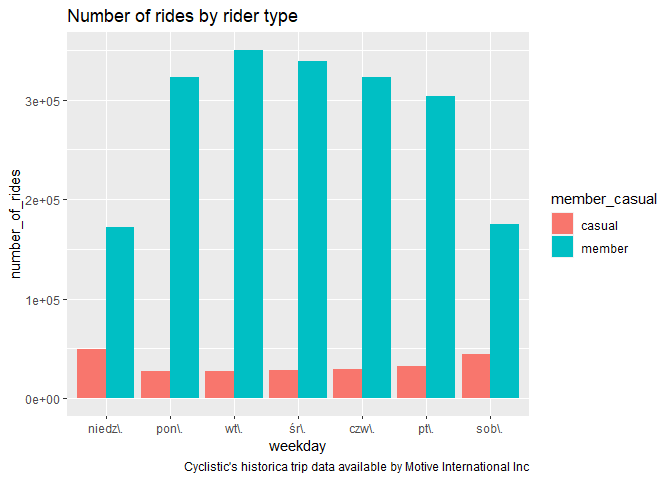

```r
all_rides_cleaned %>%
  mutate(weekday = wday(started_at, label = TRUE)) %>%
  group_by(member_casual, weekday) %>%
  summarise(number_of_rides = n(), average_duration = mean(ride_length)) %>%
  arrange(member_casual, weekday) %>%
  ggplot(aes(x = weekday, y = number_of_rides, fill = member_casual)) +
  geom_col(position = "dodge") +
  labs(title = "Number of rides by rider type", caption = "Cyclistic's historica trip data available by Motive International Inc")
```

#### Visualising the average ride duration by rider type

```
## Defaulting to continuous.
```

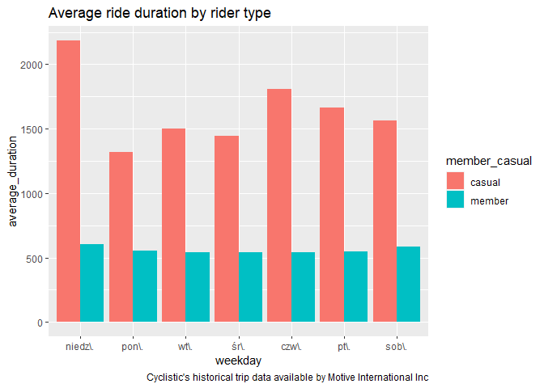

```r
all_rides_cleaned %>%
  mutate(weekday = wday(started_at, label = TRUE)) %>%
  group_by(member_casual, weekday) %>%
  summarise(number_of_rides = n(), average_duration = mean(ride_length)) %>%
  arrange(member_casual, weekday) %>%
  ggplot(aes(x = weekday, y = average_duration, fill = member_casual)) +
  geom_col(position = "dodge") +
  labs(title = "Average ride duration by rider type", caption = "Cyclistic's historical trip data available by Motive International Inc")
```